# Climate Change Conversations Study 2

Ovidia Stanoi

08/24/2026

We recruited a sample of 202 participants on Prolific to complete a 20-min elicitation survey about their climate change conversations. Participants were asked to reflect on the following behavior: **“openly sharing their thoughts, feelings, and opinions about climate change in conversations”**. Half of the sample were asked about this behavior with **“the people who are important to them”** (general group). The other half was asked about it in relation to two people: one with whom they would feel **most comfortable** and one with whom they would feel **least comfortable** talking (ego group). For each social target, participants gave open-ended responses about what they saw as the **benefits** and the **disadvantages** of sharing their thoughts about climate change with them as well as what factors would make it **easier** or **more difficult** for them to talk in the future. Participants in the ego group were also asked to list any **goals** they themselves would hope to achieve in a hypothetical conversation with these different social targets and the goals they believe the other person would hope to achieve. We used a large language model (ChatGPT-4) to identify high-level themes in the participants’ open-ended answers in an unsupervised manner. Answers were subsequently manually coded according to these themes by the research team. We present below the results.

# 1 Conversation Benefits

## Main Themes

Participants associated climate change conversations with a variety of benefits, which broadly clustered into four categories: **raising awareness** about the dangers of climate change, **influencing change** and contributing to mitigating efforts, feeling emotionally **connected**, and **sharing perspective**. We present below the percentages of the answers classified in each theme for each of the three possible conversation partners: important others broadly defined, individuals with whom participants would feel the most comfortable talking, and individuals with whom they would feel the least comfortable talking.

```r
# Count most common benefits within each theme
topic_counts <- benefits %>%
  group_by(conversation_partner) %>%
  count(theme) %>%
  mutate(percent = round(n / sum(n),2)) %>%
  filter(!(theme == "")) %>%
  arrange(conversation_partner, - percent)
kable(topic_counts)
```

| conversation_partner | theme | n | percent |
| --- | --- | --- | --- |
| Important Others | Influencing Change | 169 | 0.42 |
| Important Others | Raising Awareness | 125 | 0.31 |
| Important Others | Connection | 59 | 0.15 |
| Important Others | Perspective Sharing | 46 | 0.12 |
| Most Comfortable | Connection | 102 | 0.36 |
| Most Comfortable | Raising Awareness | 69 | 0.24 |
| Most Comfortable | Perspective Sharing | 58 | 0.20 |
| Most Comfortable | Influencing Change | 54 | 0.19 |
| Least Comfortable | Perspective Sharing | 57 | 0.37 |
| Least Comfortable | Raising Awareness | 41 | 0.27 |
| Least Comfortable | Connection | 32 | 0.21 |
| Least Comfortable | Influencing Change | 24 | 0.16 |

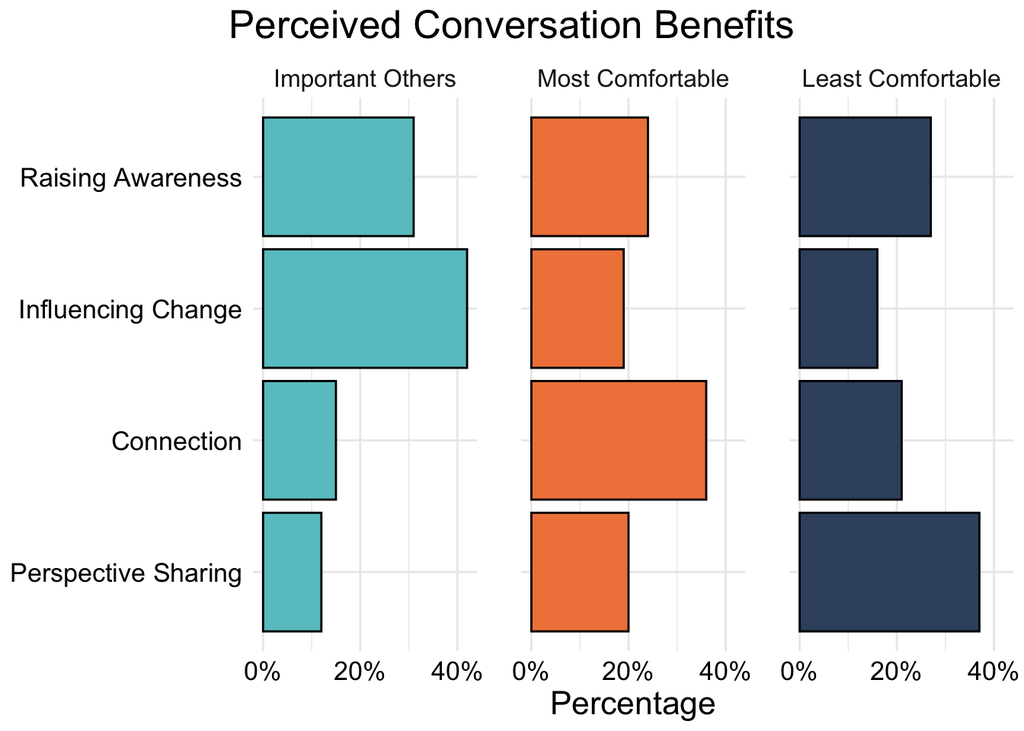

```r
# Plot results
p_benefits <- ggplot(topic_counts, aes(x = reorder(theme, percent), y = percent)) +
  geom_bar(stat = "identity", aes(fill = conversation_partner),
           color = "black") +
  coord_flip() +
  facet_wrap(~ conversation_partner) +
  labs(x = NULL,
       y = "Percentage",
       title = "Perceived Conversation Benefits") +
  scale_fill_manual(values = palette[1:3]) +
  scale_y_continuous(breaks = seq(0, .4, by = .2),
                     labels = scales::percent_format()) +
  plot_aes

# Save plot
{ragg::agg_tiff(sprintf("%s/Figures/study2_convo_benefits.tiff",
                       filedir),
              width = 1920, height = 1080,
              units = "px", res = 300)
print(p_benefits)
invisible(dev.off())}

# See plot
p_benefits
```

## Text

All responses are presented below with their assigned theme.

| conversation_partner | benefit | theme |
| --- | --- | --- |
| Important Others | enlightening others | Raising Awareness |
| Important Others | learning | Raising Awareness |
| Important Others | confirming what i am seeing, there is climate change | Perspective Sharing |
| Important Others | sharing feelings of climate change | Connection |
| Important Others | knowing we all are not alone in seeing what's happening | Perspective Sharing |
| Important Others | sharing that sadness about trump reversing climate change efforts | Connection |
| Important Others | i can let them know i am doing my part to help the enviornment and hopefully that will encourge them to do there part as well | Influencing Change |
| Important Others | honesty | Raising Awareness |
| Important Others | consciousness raising | Raising Awareness |
| Important Others | shifting opinions and possibly voting habits | Influencing Change |

[output cut: 826 more lines]

# 2 Conversation Disadvantages

## Main Themes

Perceived disadvantages of climate change conversations clustered around four themes: **disagreement** or conflict, **emotional discomfort**, being **dismissed** or judged, and the need to invest additional time and **resources**. See below the percentages of the answers classified in each theme for each of the three possible conversation partners: important others broadly defined, individuals with whom participants would feel the most comfortable talking, and individuals with whom they would feel the least comfortable talking.

```r
# Count most common disadvantages within each theme
topic_counts <- disadvantages %>%
  group_by(conversation_partner) %>%
  count(theme) %>%
  mutate(percent = round(n / sum(n),2)) %>%
  filter(!(theme == "")) %>%
  arrange(conversation_partner, - percent)
kable(topic_counts)
```

| conversation_partner | theme | n | percent |
| --- | --- | --- | --- |
| Important Others | Disagreement | 118 | 0.45 |
| Important Others | Being Dismissed | 80 | 0.31 |
| Important Others | Emotional Discomfort | 61 | 0.23 |
| Important Others | Time & Resources | 3 | 0.01 |
| Most Comfortable | Emotional Discomfort | 69 | 0.43 |
| Most Comfortable | Disagreement | 48 | 0.30 |
| Most Comfortable | Being Dismissed | 32 | 0.20 |
| Most Comfortable | Time & Resources | 11 | 0.07 |
| Least Comfortable | Disagreement | 67 | 0.47 |
| Least Comfortable | Emotional Discomfort | 39 | 0.27 |
| Least Comfortable | Being Dismissed | 36 | 0.25 |
| Least Comfortable | Time & Resources | 1 | 0.01 |

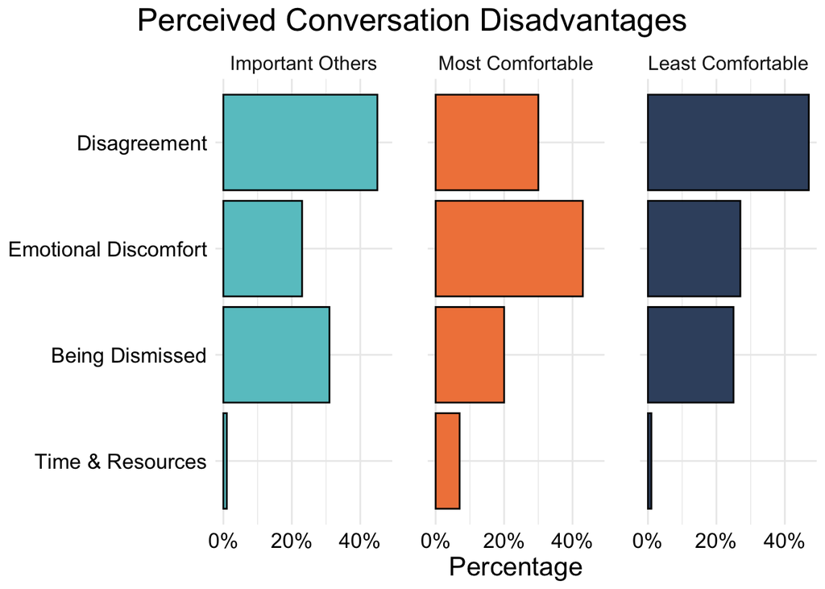

```r
# Plot results
p_disadvantages <- ggplot(topic_counts, aes(x = reorder(theme, percent), y = percent)) +
  geom_bar(stat = "identity", aes(fill = conversation_partner),
           color = "black") +
  coord_flip() +
  facet_wrap(~ conversation_partner) +
  labs(x = NULL,
       y = "Percentage",
       title = "Perceived Conversation Disadvantages") +
  scale_fill_manual(values = palette[1:3]) +
  scale_y_continuous(breaks = seq(0, .4, by = .2),
                     labels = scales::percent_format()) +
  plot_aes

# Save plot
{ragg::agg_tiff(sprintf("%s/Figures/study2_convo_disadvantages.tiff",
                       filedir),
              width = 1920, height = 1080,
              units = "px", res = 300)
print(p_disadvantages)
invisible(dev.off())}

# See plot
p_disadvantages
```

## Text

All responses are presented below with their assigned theme.

| conversation_partner | disadvantage | theme |
| --- | --- | --- |
| Important Others | possible disagreement | Disagreement |
| Important Others | makes people more anxious when talking about climate change | Emotional Discomfort |
| Important Others | they may not want to talk about it as they have a lot of things going on just to try and maintain | Being Dismissed |
| Important Others | its a gloomy future and its depressing to talk about | Emotional Discomfort |
| Important Others | annoying people | Being Dismissed |
| Important Others | individual choices don't make that big a difference | Emotional Discomfort |
| Most Comfortable | anxiety | Emotional Discomfort |
| Most Comfortable | frustration | Emotional Discomfort |
| Least Comfortable | will argue | Disagreement |
| Important Others | possible arguments | Disagreement |

[output cut: 555 more lines]

# 3 Conversation Facilitators

## Main Themes

Participants identified four clusters of factors that would make it easier to talk about climate change in the future: if they knew that their **conversation partner shared and respected their perspective**, if they had **access to reliable information** and felt confident in their knowledge, if they had more time and **resources**, and finally if they were talking to someone to whom they felt **close**. See below the percentages of the answers associated with each theme for each of the three possible conversation partners: important others broadly defined, individuals with whom participants would feel the most comfortable talking, and individuals with whom they would feel the least comfortable talking.

```r
# Count most common facilitators within each theme
topic_counts <- easy %>%
  group_by(conversation_partner) %>%
  count(theme) %>%
  mutate(percent = round(n / sum(n),2)) %>%
  filter(!(theme == "")) %>%
  arrange(conversation_partner, - percent)
kable(topic_counts)
```

| conversation_partner | theme | n | percent |
| --- | --- | --- | --- |
| Important Others | Reliable Information | 143 | 0.44 |
| Important Others | Shared Perspective | 105 | 0.32 |
| Important Others | Time & Resources | 50 | 0.15 |
| Important Others | Close Other | 26 | 0.08 |
| Most Comfortable | Reliable Information | 68 | 0.38 |
| Most Comfortable | Shared Perspective | 58 | 0.32 |
| Most Comfortable | Time & Resources | 37 | 0.20 |
| Most Comfortable | Close Other | 18 | 0.10 |
| Least Comfortable | Shared Perspective | 69 | 0.49 |
| Least Comfortable | Reliable Information | 37 | 0.26 |
| Least Comfortable | Time & Resources | 25 | 0.18 |
| Least Comfortable | Close Other | 10 | 0.07 |

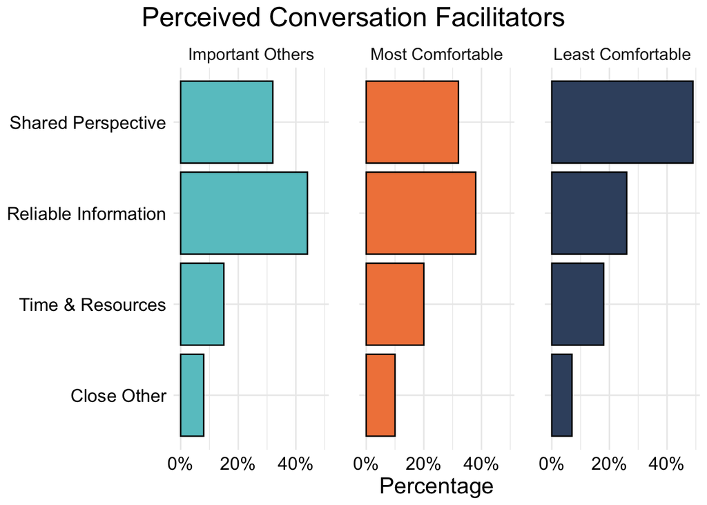

```r
# Plot results
p_facilitators <- ggplot(topic_counts, aes(x = reorder(theme, percent), y = percent)) +
  geom_bar(stat = "identity", aes(fill = conversation_partner),
           color = "black") +
  coord_flip() +
  facet_wrap(~ conversation_partner) +
  labs(x = NULL,
       y = "Percentage",
       title = "Perceived Conversation Facilitators") +
  scale_fill_manual(values = palette[1:3]) +
  scale_y_continuous(breaks = seq(0, .5, by = .2),
                     labels = scales::percent_format()) +
  plot_aes

# Save plot
{ragg::agg_tiff(sprintf("%s/Figures/study2_convo_facilitators.tiff",
                       filedir),
              width = 1920, height = 1080,
              units = "px", res = 300)
print(p_facilitators)
invisible(dev.off())}

# See plot
p_facilitators
```

## Text

All responses are presented below with their assigned theme.

| conversation_partner | facilitator | theme |
| --- | --- | --- |
| Important Others | people that can relate | Shared Perspective |
| Important Others | people that are understanding | Shared Perspective |
| Important Others | smart people | Reliable Information |
| Important Others | people with morals | Shared Perspective |
| Important Others | being specific | Reliable Information |
| Important Others | showing clear actions others can take | Reliable Information |
| Important Others | if people understood that its too late | Shared Perspective |
| Important Others | receptive audience | Shared Perspective |
| Important Others | having knowledge | Reliable Information |
| Important Others | understanding the science | Reliable Information |

[output cut: 636 more lines]

# 4 Conversation Barriers

## Main Themes

Barriers to conversations clustered into seven themes: **disagreement** with someone with opposing views, interacting with a **dismissive** conversation partner, **negative emotions**, **lack of information** and confidence in one’s communication skills, lack of time and **resources**, facing **external events** or politics, **social norms** or roles that do not sanction climate conversations. See below the percentages of the answers associated with each theme for each of the three possible conversation partners: important others broadly defined, individuals with whom participants would feel the most comfortable talking, and individuals with whom they would feel the least comfortable talking.

```r
# Count most common barriers within each theme
topic_counts <- difficult %>%
  group_by(conversation_partner) %>%
  count(theme) %>%
  mutate(percent = round(n / sum(n),2)) %>%
  filter(!(theme == "")) %>%
  arrange(conversation_partner, - percent)
kable(topic_counts)
```

| conversation_partner | theme | n | percent |
| --- | --- | --- | --- |
| Important Others | Disagreement | 76 | 0.26 |
| Important Others | Lack of Reliable Information | 59 | 0.20 |
| Important Others | Dismissive Other | 52 | 0.18 |
| Important Others | Lack of Time & Resources | 29 | 0.10 |
| Important Others | External Events & Politics | 26 | 0.09 |
| Important Others | Negative Emotions | 25 | 0.09 |
| Important Others | Social Roles & Norms | 24 | 0.08 |
| Most Comfortable | Disagreement | 48 | 0.28 |
| Most Comfortable | Negative Emotions | 28 | 0.17 |
| Most Comfortable | Dismissive Other | 27 | 0.16 |
| Most Comfortable | Lack of Time & Resources | 27 | 0.16 |
| Most Comfortable | Lack of Reliable Information | 21 | 0.12 |
| Most Comfortable | External Events & Politics | 16 | 0.09 |
| Most Comfortable | Social Roles & Norms | 2 | 0.01 |
| Least Comfortable | Disagreement | 39 | 0.26 |
| Least Comfortable | Dismissive Other | 39 | 0.26 |
| Least Comfortable | Negative Emotions | 27 | 0.18 |
| Least Comfortable | Lack of Time & Resources | 20 | 0.13 |
| Least Comfortable | Lack of Reliable Information | 15 | 0.10 |
| Least Comfortable | Social Roles & Norms | 6 | 0.04 |
| Least Comfortable | External Events & Politics | 3 | 0.02 |

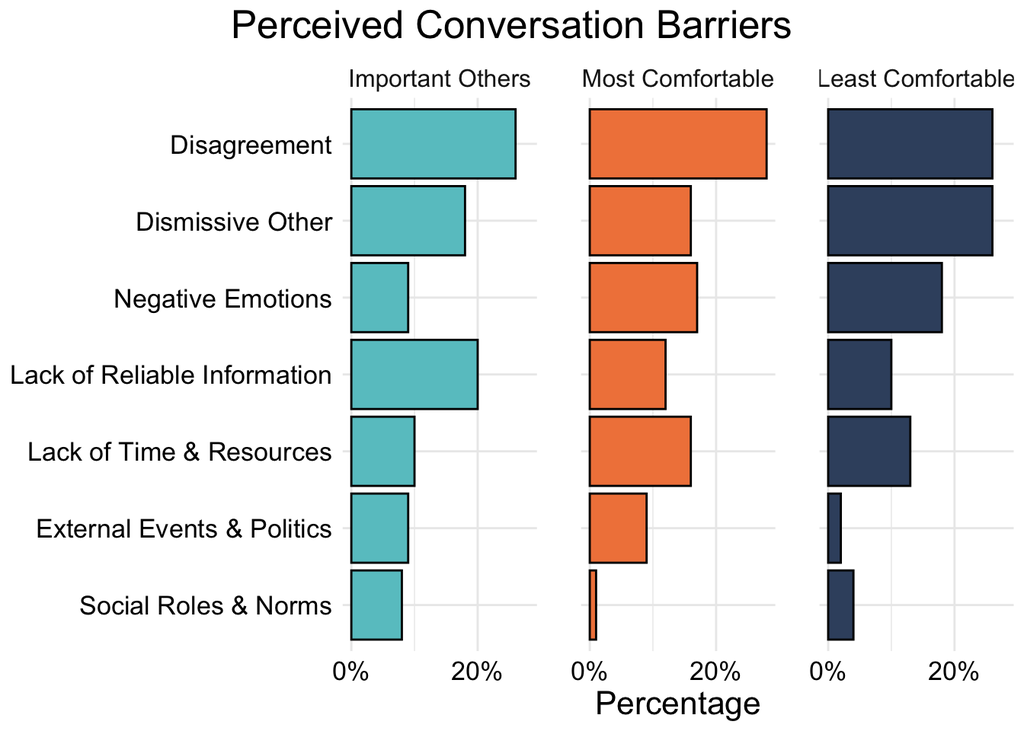

```r
# Plot results
p_barriers <- ggplot(topic_counts, aes(x = reorder(theme, percent), y = percent)) +
  geom_bar(stat = "identity", aes(fill = conversation_partner),
           color = "black") +
  coord_flip() +
  facet_wrap(~ conversation_partner) +
  labs(x = NULL,
       y = "Percentage",
       title = "Perceived Conversation Barriers") +
  scale_fill_manual(values = palette[1:3]) +
  scale_y_continuous(breaks = seq(0, .3, by = .2),
                     labels = scales::percent_format()) +
  plot_aes

# Save plot
{ragg::agg_tiff(sprintf("%s/Figures/study2_convo_barriers.tiff",
                       filedir),
              width = 1920, height = 1080,
              units = "px", res = 300)
print(p_barriers)
invisible(dev.off())}

# See plot
p_barriers
```

## Text

All responses are presented below with their assigned theme.

| conversation_partner | barrier | theme |
| --- | --- | --- |
| Important Others | stupid people that are against climate change | Disagreement |
| Important Others | stubborn people | Disagreement |
| Important Others | people who don't care | Dismissive Other |
| Important Others | people who don't listen | Dismissive Other |
| Important Others | takeing to long | Lack of Time & Resources |
| Important Others | not being specific on what actions others can take | Lack of Reliable Information |
| Important Others | false hope that we can turn this around. | Lack of Reliable Information |
| Important Others | nonresponsive/nonreceptive audience | Dismissive Other |
| Most Comfortable | an early storm | External Events & Politics |
| Most Comfortable | local damage | External Events & Politics |

[output cut: 599 more lines]

# 5 Personal Conversation Goals

## Main Themes

```r
# Count most common goals within each theme
topic_counts <- goals_self %>%
  group_by(conversation_partner) %>%
  count(theme) %>%
  mutate(percent = round(n / sum(n),2)) %>%
  filter(!(theme == "")) %>%
  arrange(conversation_partner, - percent)
kable(topic_counts)
```

| conversation_partner | theme | n | percent |
| --- | --- | --- | --- |
| Most Comfortable | Empower Action | 66 | 0.35 |
| Most Comfortable | Gain Mutual Understanding | 34 | 0.18 |
| Most Comfortable | Share Info & Persuade | 34 | 0.18 |
| Most Comfortable | Improve Emotional Well-being | 24 | 0.13 |
| Most Comfortable | Feel Heard | 16 | 0.09 |
| Most Comfortable | Feel Close | 14 | 0.07 |
| Least Comfortable | Share Info & Persuade | 54 | 0.36 |
| Least Comfortable | Empower Action | 39 | 0.26 |
| Least Comfortable | Gain Mutual Understanding | 23 | 0.16 |
| Least Comfortable | Feel Close | 14 | 0.09 |
| Least Comfortable | Feel Heard | 10 | 0.07 |
| Least Comfortable | Improve Emotional Well-being | 8 | 0.05 |

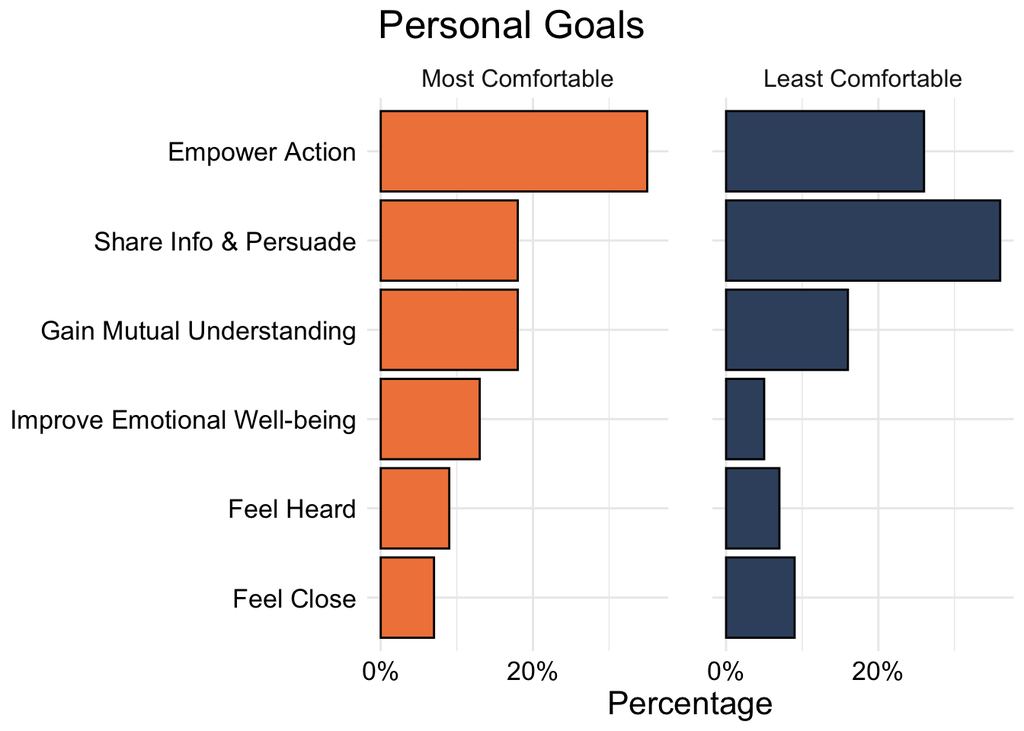

```r
# Plot results
p_goals_self <- ggplot(topic_counts, aes(x = reorder(theme, percent), y = percent)) +
  geom_bar(stat = "identity", aes(fill = conversation_partner),
           color = "black") +
  coord_flip() +
  facet_wrap(~ conversation_partner) +
  labs(x = NULL,
       y = "Percentage",
       title = "Personal Goals") +
  scale_fill_manual(values = palette[2:3]) +
  scale_y_continuous(breaks = seq(0, .4, by = .2),
                     labels = scales::percent_format()) +
  plot_aes

# Save plot
{ragg::agg_tiff(sprintf("%s/Figures/study2_convo_goals_self.tiff",
                       filedir),
              width = 1920, height = 1080,
              units = "px", res = 300)
print(p_goals_self)
invisible(dev.off())}

# See plot
p_goals_self
```

## Text

All responses are presented below with their assigned theme.

| conversation_partner | goal_self | theme |
| --- | --- | --- |
| Most Comfortable | become closer together | Feel Close |
| Most Comfortable | only perhaps to gauge how he feels about the issue | Gain Mutual Understanding |
| Least Comfortable | i would only hope to gain insight into his own views on the topic | Gain Mutual Understanding |
| Most Comfortable | knowing that i am not the only one who sees this as a major issue. | Gain Mutual Understanding |
| Least Comfortable | educating her on how this would affect her. | Share Info & Persuade |
| Least Comfortable | making her understand that climate change is real. | Share Info & Persuade |
| Most Comfortable | to gain insights | Gain Mutual Understanding |
| Most Comfortable | for motivation | Empower Action |
| Least Comfortable | to convince him to take more action | Empower Action |
| Least Comfortable | to end disagreements | Feel Close |

[output cut: 326 more lines]

# 6 Perceived Conversation Goals of Different Conversation Partners

## Main Themes

```r
# Count most common goals within each theme
topic_counts <- goals_other %>%
  group_by(conversation_partner) %>%
  count(theme) %>%
  mutate(percent = round(n / sum(n),2)) %>%
  filter(!(theme == "")) %>%
  arrange(conversation_partner, - percent)
kable(topic_counts)
```

| conversation_partner | theme | n | percent |
| --- | --- | --- | --- |
| Most Comfortable | Empower Action | 50 | 0.27 |
| Most Comfortable | Gain Mutual Understanding | 24 | 0.13 |
| Most Comfortable | Share Info & Persuade | 23 | 0.13 |
| Most Comfortable | Feel Close | 22 | 0.12 |
| Most Comfortable | Improve Emotional Well-being | 18 | 0.10 |
| Most Comfortable | Listen & Validate | 15 | 0.08 |
| Most Comfortable | Feel Heard | 13 | 0.07 |
| Most Comfortable | Improve Emotional Well-being | 11 | 0.06 |
| Most Comfortable | Protect beliefs | 4 | 0.02 |
| Most Comfortable | Suppress Conversation | 3 | 0.02 |
| Least Comfortable | Share Info & Persuade | 32 | 0.23 |
| Least Comfortable | Empower Action | 20 | 0.14 |
| Least Comfortable | Protect beliefs | 18 | 0.13 |
| Least Comfortable | Feel Close | 17 | 0.12 |
| Least Comfortable | Feel Heard | 14 | 0.10 |
| Least Comfortable | Suppress Conversation | 12 | 0.09 |
| Least Comfortable | Gain Mutual Understanding | 9 | 0.06 |
| Least Comfortable | Improve Emotional Well-being | 8 | 0.06 |
| Least Comfortable | Improve Emotional Well-being | 5 | 0.04 |
| Least Comfortable | Listen & Validate | 6 | 0.04 |

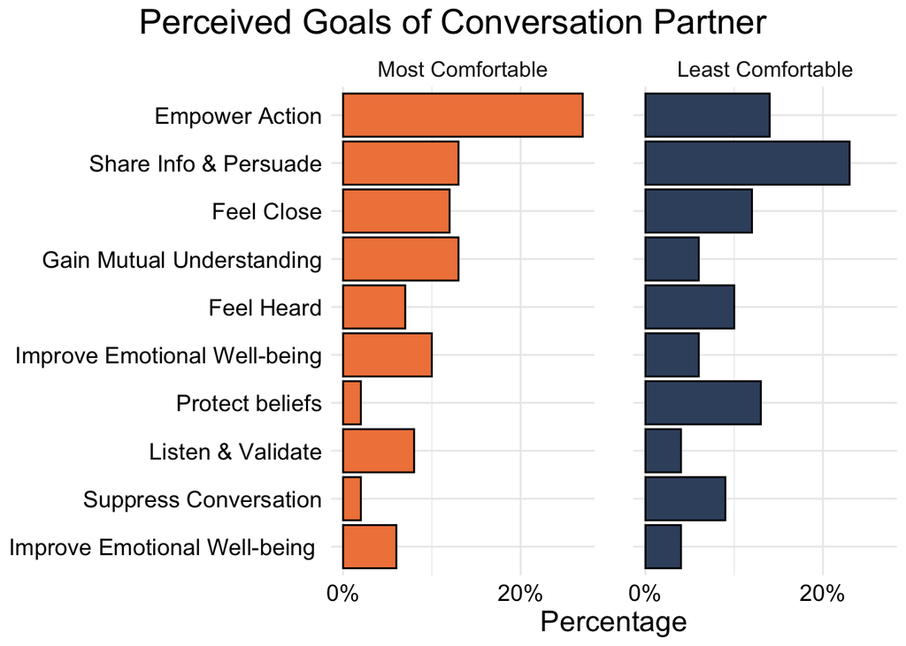

```r
# Plot results
p_goals_other <- ggplot(topic_counts, aes(x = reorder(theme, percent), y = percent)) +
  geom_bar(stat = "identity", aes(fill = conversation_partner),
           color = "black") +
  coord_flip() +
  facet_wrap(~ conversation_partner) +
  labs(x = NULL,
       y = "Percentage",
       title = "Perceived Goals of Conversation Partner") +
  scale_fill_manual(values = palette[2:3]) +
  scale_y_continuous(breaks = seq(0, .4, by = .2),
                     labels = scales::percent_format()) +
  plot_aes

# Save plot
{ragg::agg_tiff(sprintf("%s/Figures/study2_convo_goals_other.tiff",
                       filedir),
              width = 1920, height = 1080,
              units = "px", res = 300)
print(p_goals_other)
invisible(dev.off())}

# See plot
p_goals_other
```

## Text

All responses are presented below with their assigned theme.

| conversation_partner | goal_other | theme |
| --- | --- | --- |
| Least Comfortable | possibly to educate me in certain facts that he might know | Share Info & Persuade |
| Most Comfortable | a deep conversation | Gain Mutual Understanding |
| Most Comfortable | a feeling that he isn't alone in feeling concern, fear or anger. | Gain Mutual Understanding |
| Most Comfortable | to gain insights | Gain Mutual Understanding |
| Most Comfortable | for motivation | Empower Action |
| Least Comfortable | to help ease others worry. | Improve Emotional Well-being |
| Most Comfortable | have a better understanding of each other's feelings on the topic. | Gain Mutual Understanding |
| Most Comfortable | just commiserating with each other | Share Info & Persuade |
| Least Comfortable | being annoying. | Share Info & Persuade |
| Most Comfortable | have me be heard | Listen & Validate |

[output cut: 314 more lines]

# 7 Manuscript Plots

## Figure 3

Below see the script used to generate Figure 3 in the main manuscript.

```r
tiff(sprintf("%s/Figures/Figure 3. Study 2 Results Beliefs.tiff", filedir),
     width = 14, height = 8, units = "in", res = 300, compression = "lzw")

wrap_plots(p_benefits, p_disadvantages, p_facilitators, p_barriers) +
  plot_layout(axis_titles = "collect", ncol = 2) +
  plot_annotation(tag_levels = 'A', tag_suffix = '.') &
  theme(plot.tag = element_text(size = 16, face = "bold"))

invisible(dev.off())
```

## Figure 4

Below see the script used to generate Figure 4 in the main manuscript.

```r
tiff(sprintf("%s/Figures/Figure 4. Study 2 Results Goals.tiff", filedir),
     width = 14, height = 6, units = "in", res = 300, compression = "lzw")

wrap_plots(p_goals_self, p_goals_other) +
  plot_layout(axis_titles = "collect", ncol = 2) +
  plot_annotation(tag_levels = 'A', tag_suffix = '.') &
  theme(plot.tag = element_text(size = 20, face = "bold"),
        text = element_text(size = 18))

invisible(dev.off())
```